# R Notebook

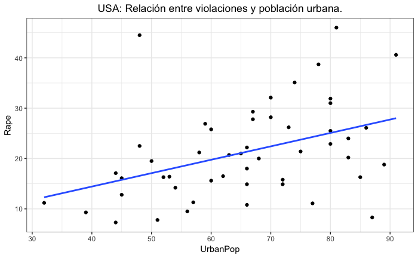

```r
#Vemos que hay una relación entre Asesinatos y violaciones, pero menos marcada que entre Asesinatos y Asaltos.
ggplot(USArrests, aes(x=UrbanPop, y=Rape)) +
  geom_point(na.rm=TRUE) +
  ggtitle ("USA: Relación entre violaciones y población urbana.") +
  theme_bw() +
  theme(plot.title = element_text(hjust = 0.5)) +
  geom_smooth(method = "lm", se = FALSE)
```

```r
#Covarianza
cov(USArrests["UrbanPop"],USArrests["Rape"])
```

```
             Rape
UrbanPop 55.76808
```

```r
#Correlación
cor(USArrests["UrbanPop"],USArrests["Rape"])
```

```
              Rape
UrbanPop 0.4113412
```

Quantiles

```r
sapply(USArrests, quantile)
```

```
     Murder Assault UrbanPop   Rape
0%    0.800      45    32.00  7.300
25%   4.075     109    54.50 15.075
50%   7.250     159    66.00 20.100
75%  11.250     249    77.75 26.175
100% 17.400     337    91.00 46.000
```

```r
#Ordenado por Asesinatos
USArrests[order(USArrests["Murder"]),]
```

|  | Murder | Assault | UrbanPop | Rape |
| --- | --- | --- | --- | --- |
| North Dakota | 0.8 | 45 | 44 | 7.3 |
| Maine | 2.1 | 83 | 51 | 7.8 |
| New Hampshire | 2.1 | 57 | 56 | 9.5 |
| Iowa | 2.2 | 56 | 57 | 11.3 |
| Vermont | 2.2 | 48 | 32 | 11.2 |
| Idaho | 2.6 | 120 | 54 | 14.2 |
| Wisconsin | 2.6 | 53 | 66 | 10.8 |
| Minnesota | 2.7 | 72 | 66 | 14.9 |
| Utah | 3.2 | 120 | 80 | 22.9 |
| Connecticut | 3.3 | 110 | 77 | 11.1 |

[output cut: 40 more lines]

```r
USArrests[order(USArrests["Rape"]),]
```

|  | Murder | Assault | UrbanPop | Rape |
| --- | --- | --- | --- | --- |
| North Dakota | 0.8 | 45 | 44 | 7.3 |
| Maine | 2.1 | 83 | 51 | 7.8 |
| Rhode Island | 3.4 | 174 | 87 | 8.3 |
| West Virginia | 5.7 | 81 | 39 | 9.3 |
| New Hampshire | 2.1 | 57 | 56 | 9.5 |
| Wisconsin | 2.6 | 53 | 66 | 10.8 |
| Connecticut | 3.3 | 110 | 77 | 11.1 |
| Vermont | 2.2 | 48 | 32 | 11.2 |
| Iowa | 2.2 | 56 | 57 | 11.3 |
| South Dakota | 3.8 | 86 | 45 | 12.8 |

[output cut: 40 more lines]

Actividad de refuerzo ——————————- Tiramos un dado una serie de veces con los siguientes resultados: dados<-c(1,2,5,3,6,4,2,1,2,4,1,5,3,2,4,1,6,2,3,1,6,2,4,2,1) - Calcula su tabla de frecuencias absolutas y relativas usando table y length - Dibuja un barplot usando table, ¿crees que el dado está equilibrado? - Calcula las medidas de centralización: media, mediana, quantiles y de dispersión: varianza, desviación típica, coeficiente de variación de pearson, rango, rango intercuartílico. - Calcula medidas de forma: asimetría, curtosis (library(fBasics))

```r
dados<-c(1,2,5,3,6,4,2,1,2,4,1,5,3,2,4,1,6,2,3,1,6,2,4,2,1)
```

```r
table(dados)
```

```
dados
1 2 3 4 5 6
6 7 3 4 2 3
```

```r
table(dados)/length(dados)
```

```
dados
   1    2    3    4    5    6
0.24 0.28 0.12 0.16 0.08 0.12
```

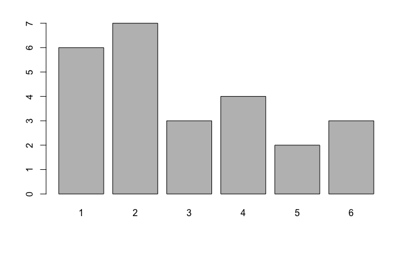

```r
barplot(table(dados))
```

¿crees que el dado está equilibrado? ——> Si, creo que entra dentro de lo normal.

```r
mean(dados)
```

```
[1] 2.92
```

```r
median(dados)
```

```
[1] 2
```

```r
sd(dados)
```

```
[1] 1.705872
```

```r
var(dados)
```

```
[1] 2.91
```

```r
quantile(dados)
```

```
  0%  25%  50%  75% 100%
   1    2    2    4    6
```

```r
#Indice de variación de Pearson es la Desviación / media
sd(dados)/mean(dados)
```

```
[1] 0.5842028
```

Calcula medidas de forma: asimetría, curtosis (library(fBasics)) Ver este enlace para entender la Curtosis y la asimetria. https://support.minitab.com/es-mx/minitab/18/help-and-how-to/statistics/basic-statistics/supporting-topics/data-concepts/how-skewness-and-kurtosis-affect-your-distribution/

```r
#install.packages("fBasics")
library(fBasics) #facilica calculo de propiedades estadísticas básicas como las que acabamos de ver.
kurtosis(dados)
```

```
[1] -1.113367
attr(,"method")
[1] "excess"
```

```r
skewness(dados)
```

```
[1] 0.5058282
attr(,"method")
[1] "moment"
```

```r
dados<-c(1,2,5,3,6,4,2,1,2,4,1,5,3,2,4,1,6,2,3,1,6,2,4,2,1,1,1,1,1,1,1,1,12,3,4,5,6,1,1,1,1,1,1,1,1,1,2,3,4,5,3,6,5,1,1,1,1,1,1,1)
skewness(dados) #Asimetria Positiva
```

```
[1] 1.786912
attr(,"method")
[1] "moment"
```

```r
print("Kurtosis")
```

```
[1] "Kurtosis"
```

```r
kurtosis(dados)
```

```
[1] 4.442051
attr(,"method")
[1] "excess"
```

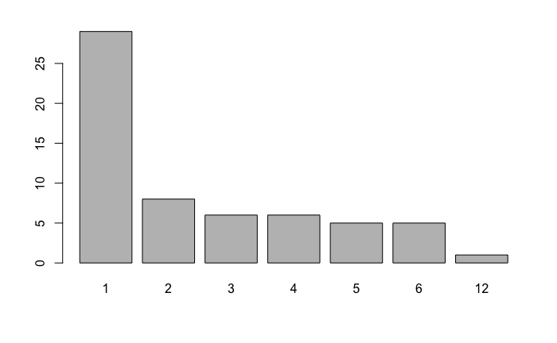

```r
barplot(table(dados))
```

```r
dados<-c(1,2,5,3,6,4,2,1,2,4,1,5,3,2,4,1,6,2,3,1,6,2,6,6,6,6,6,6,6,5,5,5,5,5,5,3,4,5,6,6,6,6,6,6,6,6,6,6,2,3,4,5,3,6,5,1,1,3,3,4,1,1,5,5,6,6)
skewness(dados) #Asimetria negativa
```

```
[1] -0.5103955
attr(,"method")
[1] "moment"
```

```r
print("Kurtosis")
```

```
[1] "Kurtosis"
```

```r
kurtosis(dados)
```

```
[1] -1.252399
attr(,"method")
[1] "excess"
```

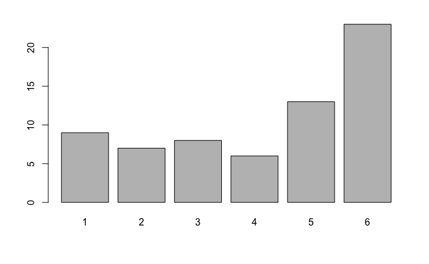

```r
barplot(table(dados))
```

```r
#tirada habitual de dados. La Asimetría tiende a cero
dados<-sample(1:6,1000,replace=T)
skewness(dados) #Asimetria tiende a cero
```

```
[1] -0.1007433
attr(,"method")
[1] "moment"
```

```r
print("Kurtosis") #La curtosis es negativa.
```

```
[1] "Kurtosis"
```

```r
kurtosis(dados)
```

```
[1] -1.25787
attr(,"method")
[1] "excess"
```

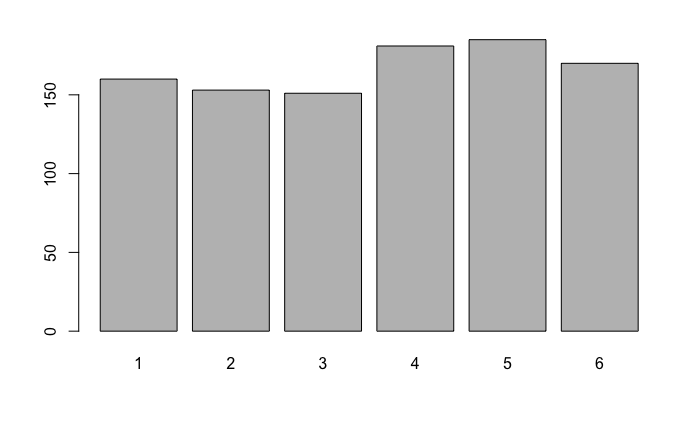

```r
barplot(table(dados))
```